# Lab 2: Linear Regression

Dean Young and Vikram Chan-Herur

#### Exercise 1

#### Create a plot of the relationship between stations and magnitude. How would you characterize the relationship? (If you see overplotting, you may want to add jitter to your points or make them transparent by playing with the alpha value.)

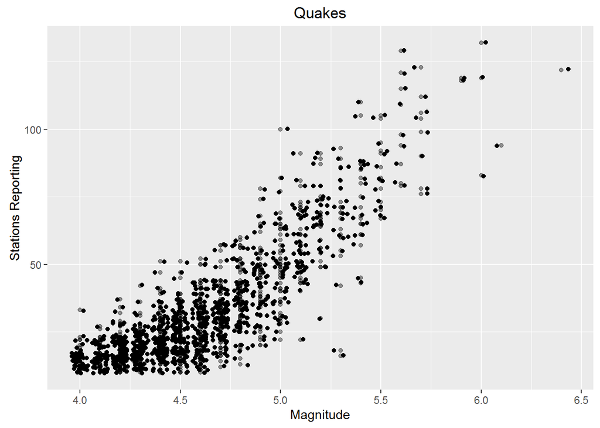

```r
ggplot(aes(x=mag,y=stations), data=quakes) + geom_point(alpha=.4) +
  geom_jitter() +
  xlab("Magnitude") + ylab("Stations Reporting") + ggtitle("Quakes")
```

#### Exercise 2

#### Before you go ahead and fit a linear model to this trend, if in fact there was no relationship between the two, what would you expect the slope to be? What about the intercept?

We would expect the slope of the line to be 0. The y-intercept should be $\bar{y}$.

#### Exercise 3

#### Ok, now go ahead and fit a linear model called m1 to the trend and add that line to the plot from exercise 1. Interpret your slope and intercept in the context of the problem.

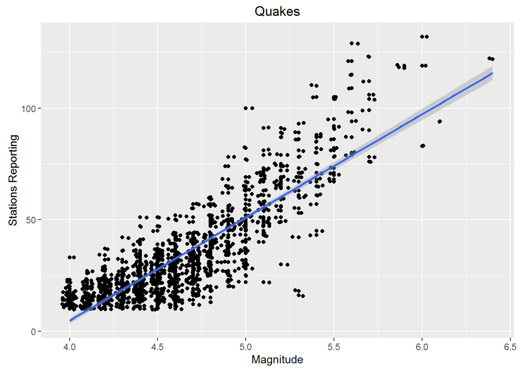

```r
m1 <- lm(stations ~ mag, data = quakes)
sum.m1 <- summary(m1)

ggplot(aes(x=mag,y=stations), data=quakes) + geom_point() + geom_jitter() +
  xlab("Magnitude") + ylab("Stations Reporting") + ggtitle("Quakes") +
  geom_smooth(method="lm")
```

```r
summary(m1)
```

```
##
## Call:
## lm(formula = stations ~ mag, data = quakes)
##
## Residuals:
##     Min      1Q  Median      3Q     Max
## -48.871  -7.102  -0.474   6.783  50.244
##
## Coefficients:
##              Estimate Std. Error t value Pr(>|t|)
## (Intercept) -180.4243     4.1899  -43.06   <2e-16 ***
## mag           46.2822     0.9034   51.23   <2e-16 ***
## ---
## Signif. codes:  0 '***' 0.001 '**' 0.01 '*' 0.05 '.' 0.1 ' ' 1
##
## Residual standard error: 11.5 on 998 degrees of freedom
## Multiple R-squared:  0.7245, Adjusted R-squared:  0.7242
## F-statistic:  2625 on 1 and 998 DF,  p-value: < 2.2e-16
```

#### Exercise 4

#### Verify the way that lm() has computed your slope correctly by using R to do the calculation using the equation for the slope based on X and Y.

```r
quakes <- quakes %>% mutate(x.dev=mag-mean(mag),y.dev=stations-mean(stations),prod=x.dev*y.dev)
ssd.mag <- (var(quakes$mag)*length(quakes$mag))
beta1 <- sum(quakes$prod)/ssd.mag
```

#### Exercise 5

#### Using R, calculate a 95% confidence interval for the slope of the model that you fit in exercise 3. Confirm the calculation using confint().

```r
### the regression as a function
f <- function(x){
  return (coef(sum.m1)[1] + (coef(sum.m1)[2] * x))
}

### calculate rss
quakes <- quakes %>% mutate(stations.resid=(stations-f(mag))^2)
rss <- sum(quakes$stations.resid)

### calculate SE beta_1^hat

se.beta1 <- sqrt(rss/m1$df)/sqrt(ssd.mag)

### calculate confidence interval

CI <- c(coef(sum.m1)[2] - qt(.975,df=m1$df)*se.beta1, coef(sum.m1)[2] + qt(.975,df=m1$df)*se.beta1)
CI
```

```
## [1] 44.51032 48.05410
```

```r
confint(m1, "mag", level = 0.95)
```

```
##        2.5 %   97.5 %
## mag 44.50944 48.05498
```

The lower bound on the slope is 44.5103249 and the upper bound on the slope is 48.0540967.

#### Exercise 6

#### How many stations do you predict would be able to detect an earthquake of magnitude 7.0?

```r
f(7)
```

```
## [1] 143.5511
```

From the regression we should expect 143.5511487 stations to detect an earthquake of magnitude 7.0, however this requires us to extrapolate. Additionally, many points from about 5.0 to the maximum (near 6.5) are above the estimated slope (heteroskedasticity), suggesting that this is an underestimate. Given that the Richter scale is logarithmic, this linear model may not adequately describe the trend.

#### Exercise 7

#### Questions 1 - 6 in this lab involve elements of data description, inference, and/or prediction. Which was the dominant goal in each question?

1. Description
2. Description
3. Inference (and description)
4. Inference (and description)
5. Inference (and description)
6. Prediction

#### Exercise 8

There is no exercise 8 on the lab.

#### Exercise 9

#### Please simulate a data set that has the same number of observations as quakes. To start, generate a vector of x’s. You can either generate your own x’s or use the exact same x’s as the quakes data.

```r
simulation <- quakes %>% select(mag,stations) # We're lazy
```

#### Exercise 10

We already made this function in exercise 5.

```r
simulation <- simulation %>% mutate(yhat = f(mag))
```

#### Exercise 11

```r
sigma2 = rss/m1$df
set.seed(76) # to get the same data every time

simulation <- simulation %>% mutate(error = rnorm(1000,mean=0,sd=sqrt(sigma2)),y=yhat+error)
```

#### Exercise 12

#### Finally, make a plot of your simulated data. How is it similar to the original data? How is it different? How might you chance your model to make it more consistent with the data?

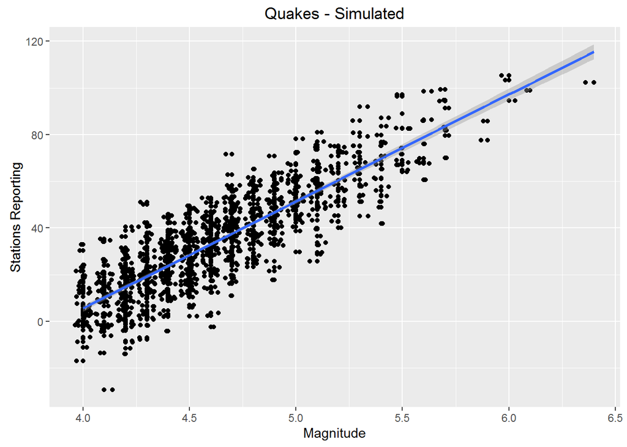

```r
ggplot(aes(x=mag,y=y), data=simulation) + geom_point() +
  geom_jitter() + geom_smooth(method="lm") +
  xlab("Magnitude") + ylab("Stations Reporting") + ggtitle("Quakes - Simulated")
```

The simulation is similar to the original data in that it shows a positive correlation between magnitude and stations reporting. However, it appears to have a more equal variance in the residuals than the original data. By using a more flexible model (especially one that doesn’t assume equal variance or linear shape) we may be able to better fit the data.

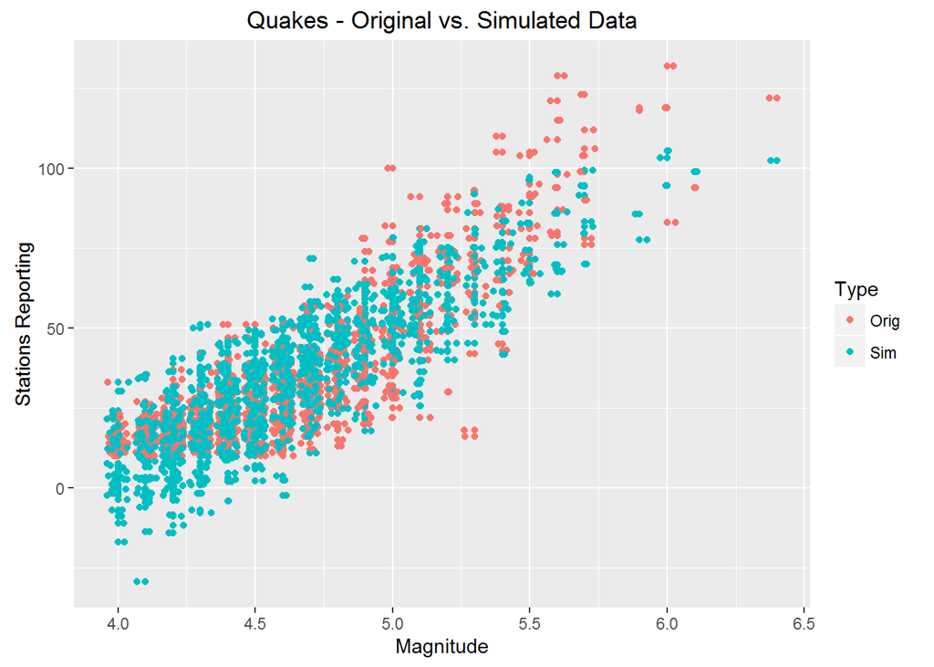

```r
sim_graph <- bind_rows(quakes %>% select(mag,stations) %>% mutate(Type="Orig"),
                       simulation %>% select(mag,y) %>% rename(stations=y) %>% mutate(Type="Sim"))

ggplot(aes(x=mag,y=stations),data=sim_graph) + geom_point(aes(col=Type)) +
  geom_jitter(aes(col=Type)) +
  xlab("Magnitude") + ylab("Stations Reporting") + ggtitle("Quakes - Original vs. Simulated Data")
```

This graph gives a good visualization comparing the two data sets.